# Smoothing Models for Dogs

# Setup

## Load Packages

```r
library(tidyverse)
```

```r
library(ggplot2)
library(forecast)
library(smooth)
theme_set(theme_bw())
```

## Load Data & Create Time Series

- Original data ranged from Oct 2013 to Aug 2020
- Subset data to drop months after Feb 2020 (impacted by COVID-19 lockdowns). This leaves 77 months (or 6 years and 5 months) of animal intake from Oct 2013 to Feb 2020
- Create time-series object with data for only the intake of **dogs**

```r
DATA_ORIGINAL <- read.csv("data/Austin_AC_Monthly_Strays.csv", stringsAsFactors = FALSE)
# str(DATA_ORIGINAL)

DATA_SUBSET <- subset(DATA_ORIGINAL, IN_YRMO <= "2020-02")

TIME_SERIES <- ts(data      = DATA_SUBSET[,c("Dog")],    # only include Dogs
                  start     = c(2013, 10),
                  end       = c(2020,  2),
                  frequency = 12)
```

Plot the intake of stray dogs

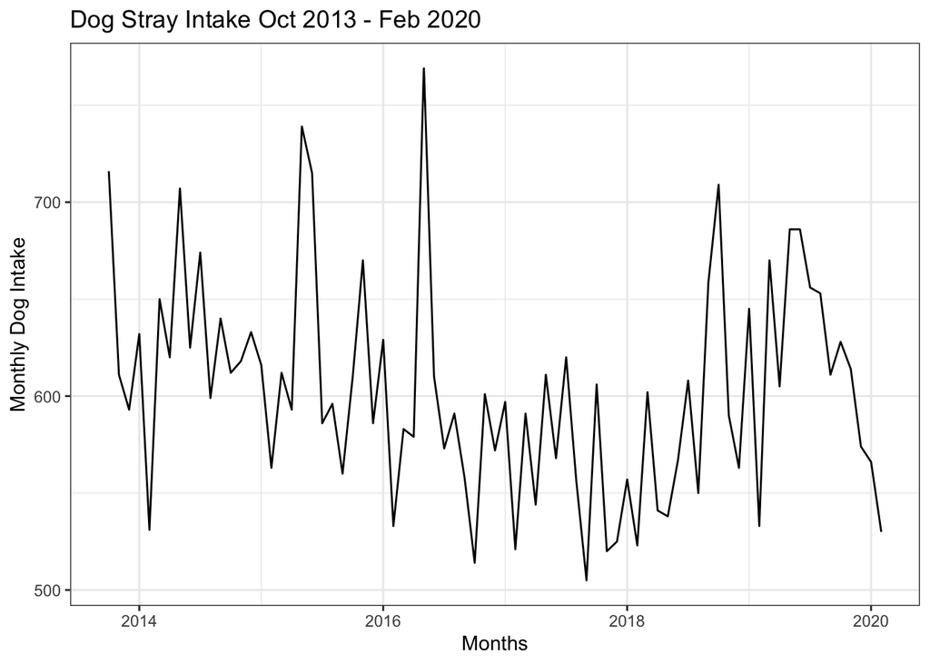

```r
label_title = "Dog Stray Intake Oct 2013 - Feb 2020"
label_xaxis = "Months"
label_yaxis = "Monthly Dog Intake"

autoplot(TIME_SERIES) +
  ggtitle(label_title) +
  xlab(label_xaxis) + ylab(label_yaxis) +
  theme(legend.position = "bottom") +
  guides(colour=guide_legend(title=""))
```

## Partition Data

- Training - 65 months or 5 years and 5 months (Oct 2013 to Feb 2019)
- Test - last 12 months (Mar 2019 to Feb 2020)

```r
TS_TRNG_SET <- window(TIME_SERIES,
                      start=c(2013, 10),
                      end  =c(2019,  2))

TS_TEST_SET <- window(TIME_SERIES,
                      start=c(2019,  3),
                      end  =c(2020,  2))

N_TEST_SET <- length(TS_TEST_SET)

TS_TEST_SET
```

```
##      Jan Feb Mar Apr May Jun Jul Aug Sep Oct Nov Dec
## 2019         670 605 686 686 656 653 611 628 614 574
## 2020 566 530
```

# Smoothing Models

## Simple Moving Average

Use `smooth::sma()`

**Fit Model**

```r
# order = NULL to select optimal window for moving average.

MODEL_SMA <- sma(TS_TRNG_SET, order=NULL, holdout=FALSE, silent="none")
```

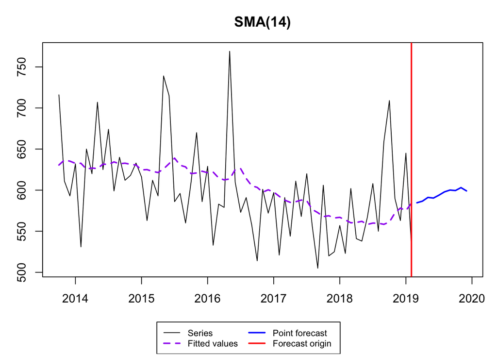

```r
summary(MODEL_SMA)
```

```
## Time elapsed: 0.08 seconds
## Model estimated: SMA(14)
## Initial values were produced using backcasting.
##
## Loss function type: MSE; Loss function value: 2821.1635
## Error standard deviation: 53.9511
## Sample size: 65
## Number of estimated parameters: 2
## Number of degrees of freedom: 63
## Information criteria:
##      AIC     AICc      BIC     BICc
## 704.8808 705.0744 709.2296 709.6336
```

Optimal width/window is last 14 observations (as noted in title of chart output).

**Forecast/Predict Values for Test Set**

```r
FC_SMA <- forecast(MODEL_SMA, h=N_TEST_SET)
FC_SMA$mean
```

```
##           Jan      Feb      Mar      Apr      May      Jun      Jul      Aug
## 2019                   584.6429 586.6173 591.1614 590.3873 593.9149 597.9088
## 2020 591.2497 591.3389
##           Sep      Oct      Nov      Dec
## 2019 600.1166 599.5535 603.0931 599.0997
## 2020
```

Plot

- the full time series of dog intake (includes both the training and test data)
- the fitted values
- the forecast for the next 12 months

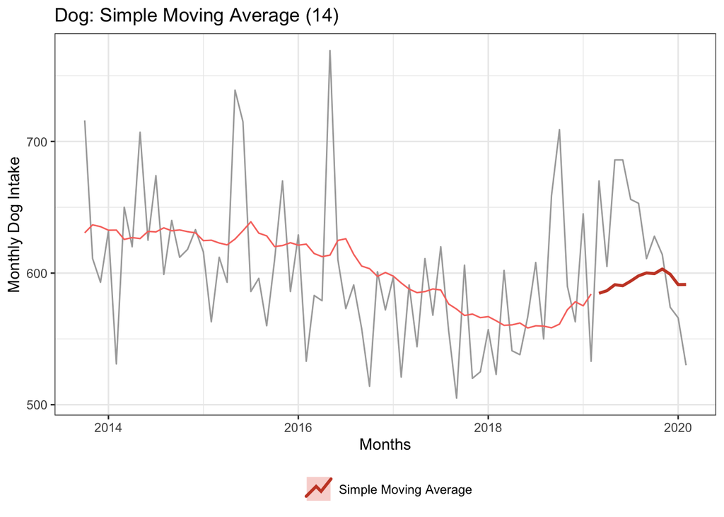

```r
autoplot(TIME_SERIES, color="darkgray") +
  ggtitle("Dog: Simple Moving Average (14)") +
  xlab(label_xaxis) + ylab(label_yaxis) +
  theme(legend.position = "bottom") +
  guides(colour=guide_legend(title="")) +

  # fitted values
  autolayer(fitted(MODEL_SMA), series="Simple Moving Average", lwd=0.5) +

  # forecasted values
  autolayer(FC_SMA,            series="Simple Moving Average", PI=FALSE, lwd=1, lty=1)
```

**Assess Accuracy of Model**

Manually Calculate

```r
ACTUAL    <- as.numeric(TS_TEST_SET)
PREDICTED <- as.numeric(FC_SMA$forecast)

MODEL_ACCURACY <- data.frame(
  Model    = "Simple Moving Average",
  RMSE     = Metrics::rmse(ACTUAL, PREDICTED),
  MAE      = Metrics::mae( ACTUAL, PREDICTED),
  MAPE     = Metrics::mape(ACTUAL, PREDICTED),
  AdjRsqrd = NA
)

MODEL_COMPARISON <- MODEL_ACCURACY
MODEL_COMPARISON
```

```
##                   Model     RMSE      MAE       MAPE AdjRsqrd
## 1 Simple Moving Average 56.80825 47.77437 0.07494688       NA
```

On average, forecast off by 57 dogs per month (or about 7.5%)

## Simple Exponential Smoothing (Level)

This approach is inappropriate since the time series has trend and seasonality, but walk through the steps for experience.

Also, recall SES has a flat forecast beyond the one-step ahead.

Use `ses()` from `forecast` pacakge where ses, holt and hw are simply convenient wrapper functions for forecast(ets(…)).

**Fit Model & Forecast in One-Step**

```r
FC_SES <- forecast::ses(TS_TRNG_SET, h=N_TEST_SET)

FC_SES$model
```

```
## Simple exponential smoothing
##
## Call:
##  forecast::ses(y = TS_TRNG_SET, h = N_TEST_SET)
##
##   Smoothing parameters:
##     alpha = 0.1087
##
##   Initial states:
##     l = 628.9678
##
##   sigma:  55.0494
##
##      AIC     AICc      BIC
## 796.3738 796.7673 802.8970
```

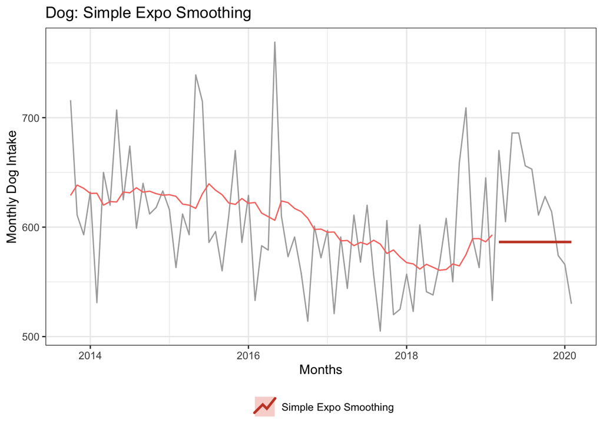

```r
autoplot(TIME_SERIES, color="darkgray") +
  ggtitle("Dog: Simple Expo Smoothing") +
  xlab(label_xaxis) + ylab(label_yaxis) +
  theme(legend.position = "bottom") +
  guides(colour=guide_legend(title="")) +

  # fitted values
  autolayer(fitted(FC_SES),    series="Simple Expo Smoothing", lwd=0.5) +

  # forecasted values
  autolayer(FC_SES,            series="Simple Expo Smoothing", PI=FALSE, lwd=1, lty=1)
```

Forecasted Values

Again, SES has flat forecast estimates 1 step out and then carries that single value forward through the entire forecast period.

```r
FC_SES$mean
```

```
##           Jan      Feb      Mar      Apr      May      Jun      Jul      Aug
## 2019                   586.4417 586.4417 586.4417 586.4417 586.4417 586.4417
## 2020 586.4417 586.4417
##           Sep      Oct      Nov      Dec
## 2019 586.4417 586.4417 586.4417 586.4417
## 2020
```

```r
summary(residuals(FC_SES))
```

```
##    Min. 1st Qu.  Median    Mean 3rd Qu.    Max.
## -99.960 -40.116 -13.938  -6.019   8.042 162.754
```

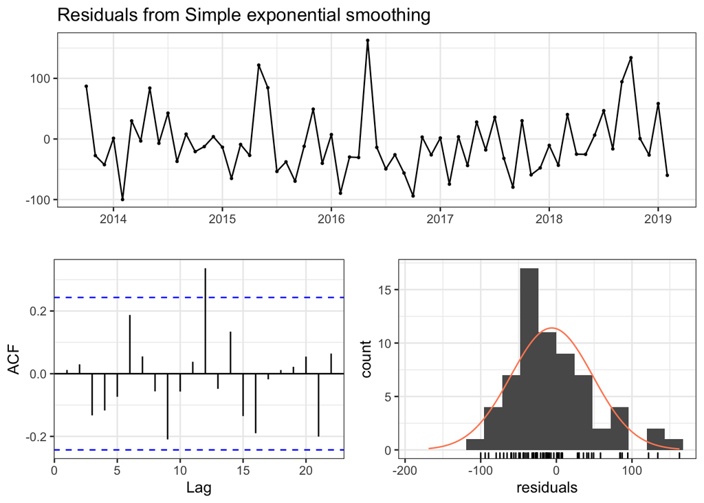

```
##
##  Ljung-Box test
##
## data:  Residuals from Simple exponential smoothing
## Q* = 19.026, df = 11, p-value = 0.06062
##
## Model df: 2.   Total lags used: 13
```

```r
checkresiduals(FC_SES)
```

- Not much autocorrelation - lag 12 above significance line. Ljung-Box test not significant (p-value 0.061).
- Mean of residuals not zero (-6.019). Histogram not normally distributed - peak on negative side. So some bias in the model.

```r
accuracy(FC_SES, TS_TEST_SET)
```

```
##                     ME     RMSE      MAE       MPE     MAPE      MASE
## Training set -6.018883 54.19589 41.88115 -1.725869 6.945186 0.9522526
## Test set     36.808257 60.04611 51.69580  5.338113 8.076204 1.1754085
##                    ACF1 Theil's U
## Training set 0.01173248        NA
## Test set     0.48561782  1.436564
```

Manual Calculate

```r
ACTUAL    <- as.numeric(TS_TEST_SET)
PREDICTED <- as.numeric(FC_SES$mean)

MODEL_ACCURACY <- data.frame(
  Model    = "Simple Expo Smoothing",
  RMSE     = Metrics::rmse(ACTUAL, PREDICTED),
  MAE      = Metrics::mae( ACTUAL, PREDICTED),
  MAPE     = Metrics::mape(ACTUAL, PREDICTED),
  AdjRsqrd = NA
)

MODEL_COMPARISON <- rbind(MODEL_COMPARISON, MODEL_ACCURACY)
MODEL_COMPARISON
```

```
##                   Model     RMSE      MAE       MAPE AdjRsqrd
## 1 Simple Moving Average 56.80825 47.77437 0.07494688       NA
## 2 Simple Expo Smoothing 60.04611 51.69580 0.08076204       NA
```

SES slightly worse than SMA. On average, forecast off by 60 dogs per month (or about 8%)

## Holt Smoothing (Level & Trend)

Smooth level and trends. Again not the most appropriate given our data has some seasonality.

```r
FC_HOLT <- forecast::holt(TS_TRNG_SET, h=N_TEST_SET,
                          exponential = FALSE,
                          damped      = TRUE)

FC_HOLT$model
```

```
## Damped Holt's method
##
## Call:
##  forecast::holt(y = TS_TRNG_SET, h = N_TEST_SET, damped = TRUE,
##
##  Call:
##      exponential = FALSE)
##
##   Smoothing parameters:
##     alpha = 0.0473
##     beta  = 1e-04
##     phi   = 0.98
##
##   Initial states:
##     l = 635.0275
##     b = -1.6211
##
##   sigma:  55.1769
##
##      AIC     AICc      BIC
## 799.5031 800.9513 812.5494
```

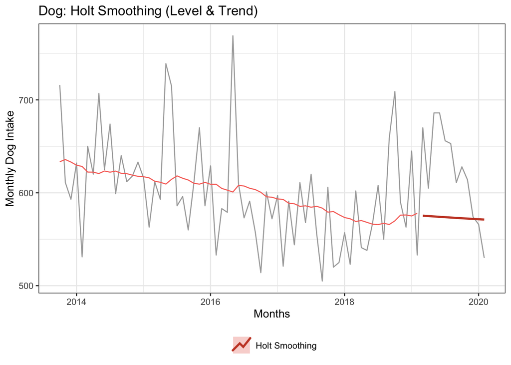

```r
autoplot(TIME_SERIES, color="darkgray") +
  ggtitle("Dog: Holt Smoothing (Level & Trend)") +
  xlab(label_xaxis) + ylab(label_yaxis) +
  theme(legend.position = "bottom") +
  guides(colour=guide_legend(title="")) +

  # fitted values
  autolayer(fitted(FC_HOLT),    series="Holt Smoothing", lwd=0.5) +

  # forecasted values
  autolayer(FC_HOLT,            series="Holt Smoothing", PI=FALSE, lwd=1, lty=1)
```

Forecasted Values

Slightly downward trend.

```r
FC_HOLT$mean
```

```
##           Jan      Feb      Mar      Apr      May      Jun      Jul      Aug
## 2019                   575.3775 574.9584 574.5477 574.1452 573.7508 573.3643
## 2020 571.5445 571.2021
##           Sep      Oct      Nov      Dec
## 2019 572.9855 572.6142 572.2504 571.8939
## 2020
```

```r
summary(residuals(FC_HOLT))
```

```
##     Min.  1st Qu.   Median     Mean  3rd Qu.     Max.
## -97.3556 -30.1950  -8.6033  -0.3449  19.8543 168.1418
```

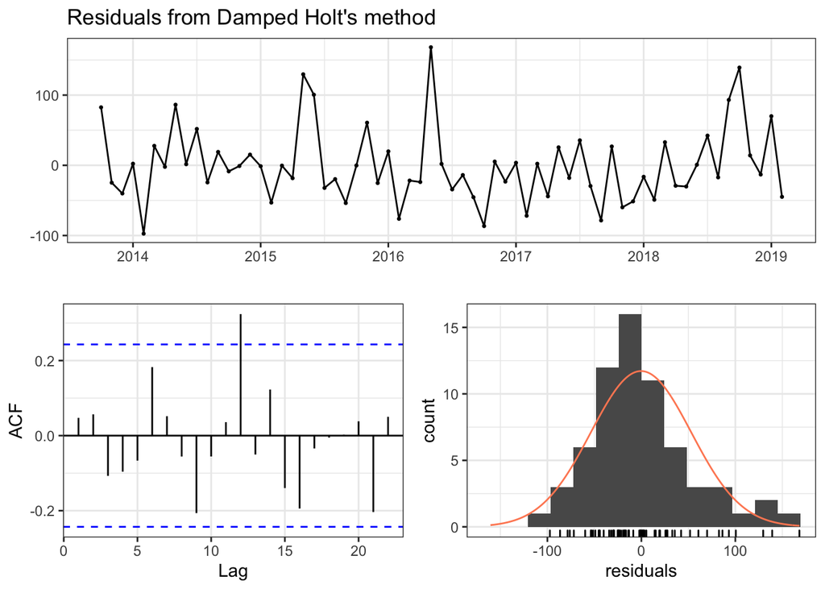

```
##
##  Ljung-Box test
##
## data:  Residuals from Damped Holt's method
## Q* = 17.56, df = 8, p-value = 0.02478
##
## Model df: 5.   Total lags used: 13
```

```r
checkresiduals(FC_HOLT)
```

- Some autocorrelation? - lag 12 above significance line. Ljung-Box test is significant (p-value 0.025). There is still some information in the time series the model is not extracting.
- Mean of residuals not zero (-0.3449). Histogram is more normally (than SES) but some peak on negative side, and small bump on right tail. Maybe some slight bias in the model.

```r
accuracy(FC_HOLT, TS_TEST_SET)
```

```
##                      ME     RMSE      MAE        MPE     MAPE      MASE
## Training set -0.3449311 53.01221 39.07388 -0.7876061 6.432001 0.8884237
## Test set     50.0304592 68.24240 57.82155  7.4856460 8.944574 1.3146900
##                   ACF1 Theil's U
## Training set 0.0472535        NA
## Test set     0.4754796  1.618576
```

Manually Calculate

```r
ACTUAL    <- as.numeric(TS_TEST_SET)
PREDICTED <- as.numeric(FC_HOLT$mean)

MODEL_ACCURACY <- data.frame(
  Model    = "Holt Smoothing",
  RMSE     = Metrics::rmse(ACTUAL, PREDICTED),
  MAE      = Metrics::mae( ACTUAL, PREDICTED),
  MAPE     = Metrics::mape(ACTUAL, PREDICTED),
  AdjRsqrd = NA
)

MODEL_COMPARISON <- rbind(MODEL_COMPARISON, MODEL_ACCURACY)
MODEL_COMPARISON
```

```
##                   Model     RMSE      MAE       MAPE AdjRsqrd
## 1 Simple Moving Average 56.80825 47.77437 0.07494688       NA
## 2 Simple Expo Smoothing 60.04611 51.69580 0.08076204       NA
## 3        Holt Smoothing 68.24240 57.82155 0.08944574       NA
```

Holt Smoothing (Level & Trend) accuracy is worse the SES. On average, model forecast off by 68 dogs per month (about 9%)

## Holt Winters Smoothing (Level, Trend, Seasonality)

```r
FC_HW <- forecast::hw(TS_TRNG_SET, h=N_TEST_SET,
                      exponential = FALSE, damped = TRUE,
                      seasonal    = "additive")
#                      seasonal    = "multiplicative")

FC_HW$model
```

```
## Damped Holt-Winters' additive method
##
## Call:
##  forecast::hw(y = TS_TRNG_SET, h = N_TEST_SET, seasonal = "additive",
##
##  Call:
##      damped = TRUE, exponential = FALSE)
##
##   Smoothing parameters:
##     alpha = 0.1679
##     beta  = 0.0042
##     gamma = 3e-04
##     phi   = 0.8003
##
##   Initial states:
##     l = 642.6748
##     b = -3.0443
##     s = -24.5486 -19.143 19.04 19.7404 77.4848 -21.6911
##            9.4155 -57.3569 12.8827 -18.157 1.3248 1.0084
##
##   sigma:  49.459
##
##      AIC     AICc      BIC
## 794.7768 809.6464 833.9158
```

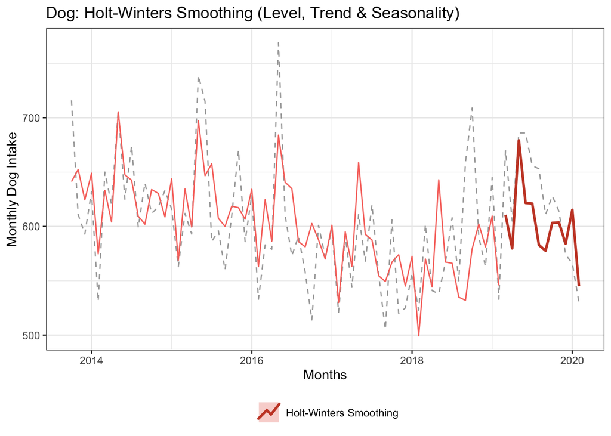

```r
autoplot(TIME_SERIES, color="darkgray", lty=2) +
  ggtitle("Dog: Holt-Winters Smoothing (Level, Trend & Seasonality)") +
  xlab(label_xaxis) + ylab(label_yaxis) +
  theme(legend.position = "bottom") +
  guides(colour=guide_legend(title="")) +

  # fitted values
  autolayer(fitted(FC_HW),      series="Holt-Winters Smoothing", lwd=0.5) +

  # forecasted values
  autolayer(FC_HW,              series="Holt-Winters Smoothing", PI=FALSE, lwd=1, lty=1)
```

Looks like a better fit.

```r
summary(residuals(FC_HW))
```

```
##     Min.  1st Qu.   Median     Mean  3rd Qu.     Max.
## -104.960  -23.264   -8.662   -2.330   16.855  129.670
```

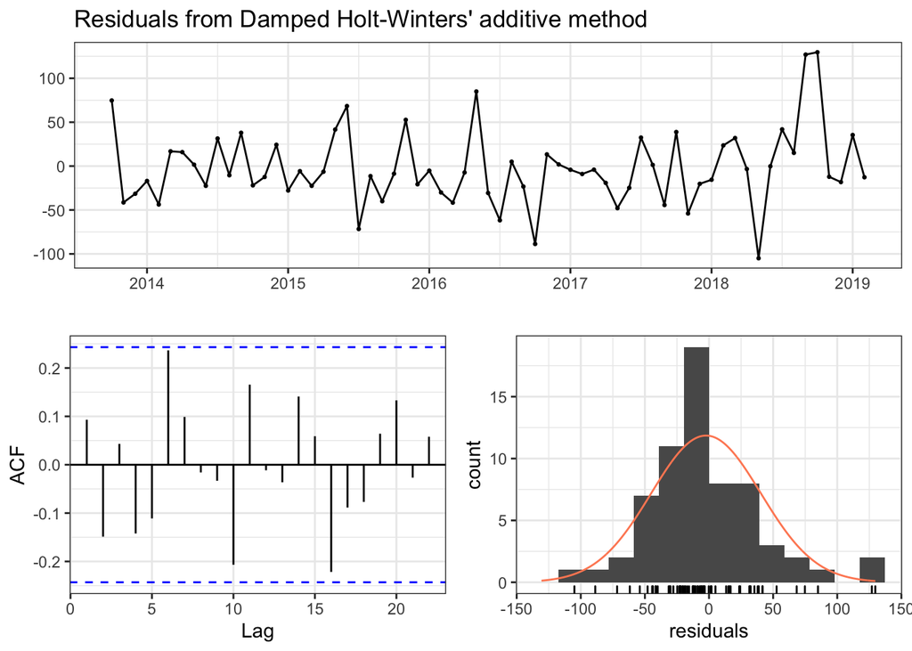

```
##
##  Ljung-Box test
##
## data:  Residuals from Damped Holt-Winters' additive method
## Q* = 25.006, df = 3, p-value = 1.539e-05
##
## Model df: 17.   Total lags used: 20
```

```r
checkresiduals(FC_HW)
```

- Autocorrelation? - no lags above significance line. Ljung-Box test is strongly significant (p-value 1.539e-05). Indicating the residuals don’t appear to be white noise - so perhaps some more information can be extracted to forecast the time-series.
- Mean of residuals not zero (-2.330). Histogram kind of normally distribute, but peak on negative side, and bump on right tail/outliers. Maybe some bias in the model.

```r
accuracy(FC_HW, TS_TEST_SET)
```

```
##                     ME     RMSE      MAE       MPE     MAPE      MASE
## Training set -2.329564 42.50199 31.49211 -0.814601 5.187709 0.7160367
## Test set     21.229454 39.85275 33.63260  3.102933 5.320167 0.7647051
##                    ACF1 Theil's U
## Training set 0.09308936        NA
## Test set     0.47160025 0.9284378
```

Manually Calculate

```r
ACTUAL    <- as.numeric(TS_TEST_SET)
PREDICTED <- as.numeric(FC_HW$mean)

MODEL_ACCURACY <- data.frame(
  Model    = "Holt-Winters Smoothing",
  RMSE     = Metrics::rmse(ACTUAL, PREDICTED),
  MAE      = Metrics::mae( ACTUAL, PREDICTED),
  MAPE     = Metrics::mape(ACTUAL, PREDICTED),
  AdjRsqrd = NA
)

MODEL_COMPARISON <- rbind(MODEL_COMPARISON, MODEL_ACCURACY)
MODEL_COMPARISON
```

```
##                    Model     RMSE      MAE       MAPE AdjRsqrd
## 1  Simple Moving Average 56.80825 47.77437 0.07494688       NA
## 2  Simple Expo Smoothing 60.04611 51.69580 0.08076204       NA
## 3         Holt Smoothing 68.24240 57.82155 0.08944574       NA
## 4 Holt-Winters Smoothing 39.85275 33.63260 0.05320167       NA
```

Much better results when using appropriate technique (factor in seasonality). On average forecast off by 40 dogs per month (5%).

## (stat) Holt Winters Smoothing (Level, Trend, Seasonality)

Use `HoltWinters()` from the `stats` package rather than the equivalent function in the `forecast` package which uses `ets()` under the covers.

Notes on difference between stats::HoltWinters() and forecast::hw()

- https://stats.stackexchange.com/questions/312811/implementation-difference-between-holtwinters-and-hw-functions-of-rs-forecast-p
- https://robjhyndman.com/hyndsight/estimation2/

**Fit Model**

```r
MODEL_HWstat <- stats::HoltWinters(TS_TRNG_SET)
MODEL_HWstat
```

```
## Holt-Winters exponential smoothing with trend and additive seasonal component.
##
## Call:
## stats::HoltWinters(x = TS_TRNG_SET)
##
## Smoothing parameters:
##  alpha: 0.1538457
##  beta : 0
##  gamma: 0.08231473
##
## Coefficients:
##             [,1]
## a   601.50146373
## b    -0.01704545
## s1   -8.46823080
## s2  -15.40151394
## s3   77.59403858
## s4    3.95262833
## s5   36.06608128
## s6  -25.80408233
## s7    4.96622167
## s8   -3.06950870
## s9   -5.49747044
## s10  -5.92420939
## s11  -5.77068092
## s12 -63.98093732
```

Plot the resulting smoothed components

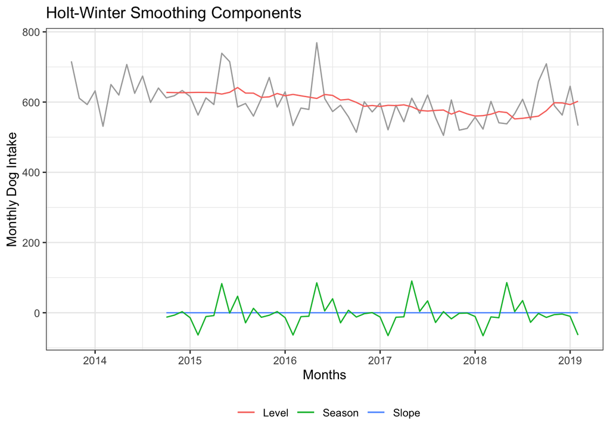

```r
autoplot(MODEL_HWstat$x, series="Data", color="darkgray") +
  autolayer(MODEL_HWstat$fitted[,2], series="Level") +
  autolayer(MODEL_HWstat$fitted[,3], series="Slope") +
  autolayer(MODEL_HWstat$fitted[,4], series="Season") +

  ggtitle("Holt-Winter Smoothing Components") +
  xlab(label_xaxis) + ylab(label_yaxis) +
  theme(legend.position = "bottom") +
  guides(colour=guide_legend(title=""))
```

```r
# ggsave(filename = "figures/02_MOD_Dog_HoltWinters_Smoothing.png",
#        height=4, width=6, units="in")
```

**Forecast/Predict Values for Test Set**

```r
FC_HWstat <- predict(MODEL_HWstat, n.ahead = N_TEST_SET)
FC_HWstat
```

```
##           Jan      Feb      Mar      Apr      May      Jun      Jul      Aug
## 2019                   593.0162 586.0659 679.0444 605.3859 637.4823 575.5951
## 2020 595.5433 537.3160
##           Sep      Oct      Nov      Dec
## 2019 606.3484 598.2956 595.8506 595.4068
## 2020
```

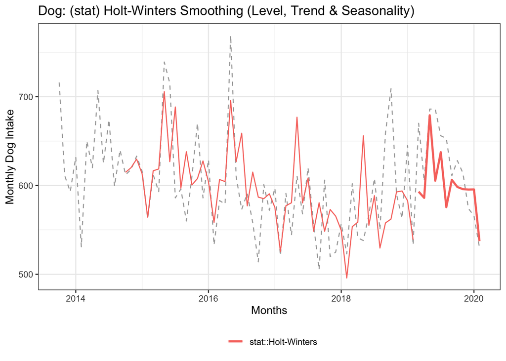

```r
autoplot(TIME_SERIES, color="darkgray", lty=2) +
  ggtitle("Dog: (stat) Holt-Winters Smoothing (Level, Trend & Seasonality)") +
  xlab(label_xaxis) + ylab(label_yaxis) +
  theme(legend.position = "bottom") +
  guides(colour=guide_legend(title="")) +

  # fitted values
  autolayer(fitted(MODEL_HWstat)[,c("xhat")], series="stat::Holt-Winters", lwd=0.5) +

  # forecasted values
  autolayer(FC_HWstat,                        series="stat::Holt-Winters", lwd=1, lty=1)
```

Plot comparison with Benchmark (Seasonal Naive)

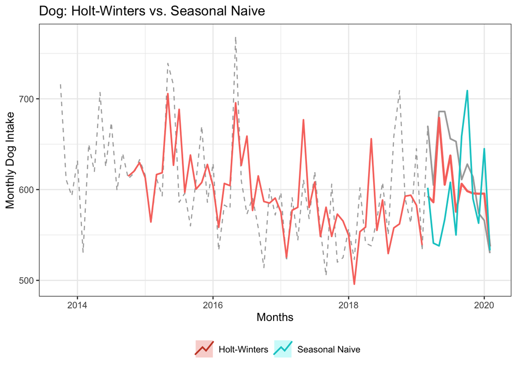

```r
# create seasonal naive forecast for comparison
FC_SEASONAL_NAIVE <- snaive(TS_TRNG_SET, h=N_TEST_SET)

autoplot(TIME_SERIES, color="darkgray", lty=2) +
  ggtitle("Dog: Holt-Winters vs. Seasonal Naive") +
  xlab(label_xaxis) + ylab(label_yaxis) +
  theme(legend.position = "bottom") +
  guides(colour=guide_legend(title="")) +

  # test set
  autolayer(TS_TEST_SET, color="darkgray", lwd=.75, lty=1) +

  # fitted values
  autolayer(fitted(MODEL_HWstat)[,c("xhat")], series="Holt-Winters", lwd=0.75) +

  # forecasted values
  autolayer(FC_HWstat,                        series="Holt-Winters", lwd=1, lty=1) +

  # seasonal naive forecast
  autolayer(FC_SEASONAL_NAIVE,         series="Seasonal Naive", PI=FALSE, lwd=.75, lty=1)
```

```r
# ggsave(filename = "figures/02_MOD_Dog_HoltWinters_vs_Naive.png",
#           height=4, width=6, units="in")
```

```r
summary(residuals(MODEL_HWstat))
```

```
##     Min.  1st Qu.   Median     Mean  3rd Qu.     Max.
## -117.947  -25.575   -2.081   -3.071   19.503  146.846
```

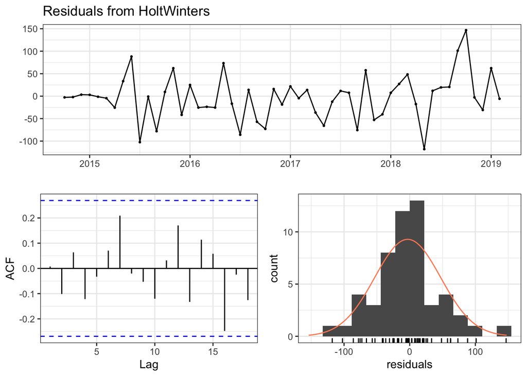

```r
checkresiduals(MODEL_HWstat)
```

- Does not look like any autocorrelation.
- Looks a little bias - tends to under estimate.

**Assess Accuracy**

```r
ACTUAL    <- as.numeric(TS_TEST_SET)
PREDICTED <- as.numeric(FC_HWstat)

MODEL_ACCURACY <- data.frame(
  Model    = "stat::Holt-Winters",
  RMSE     = Metrics::rmse(ACTUAL, PREDICTED),
  MAE      = Metrics::mae( ACTUAL, PREDICTED),
  MAPE     = Metrics::mape(ACTUAL, PREDICTED),
  AdjRsqrd = NA
)

MODEL_COMPARISON <- rbind(MODEL_COMPARISON, MODEL_ACCURACY)
MODEL_COMPARISON
```

```
##                    Model     RMSE      MAE       MAPE AdjRsqrd
## 1  Simple Moving Average 56.80825 47.77437 0.07494688       NA
## 2  Simple Expo Smoothing 60.04611 51.69580 0.08076204       NA
## 3         Holt Smoothing 68.24240 57.82155 0.08944574       NA
## 4 Holt-Winters Smoothing 39.85275 33.63260 0.05320167       NA
## 5     stat::Holt-Winters 42.60713 32.51515 0.05069853       NA
```

Similar accuracy as forecast’s implementation of Holt-Winters Smoothing

```r
#write_csv(MODEL_COMPARISON, "data/results_dog_smoothing.csv")
```